# This is a title

# Cleaning data Question 4

Import “personality-raw.txt” into R. Remove the V00 column. Create two new columns from the current column “date_test”: year and week. Stack Overflow may help: https://stackoverflow.com/questions/22439540/how-to-get-week-numbers-from-dates … Sort the new data frame by YEAR, WEEK so the newest tests are first … The newest tests (e.g., 2020 or 2019) are at the top of the data frame. Then remove duplicates using the unique function based on the column “md5_email”. Save the data frame in the same “pipe-delimited format” ( | is a pipe ) with the headers. You will keep the new data frame as “personality-clean.txt” for future work (you will not upload it at this time). In the homework, for this tasks, report how many records your raw dataset had and how many records your clean dataset has.

```r
source(paste0(local.path,"/functions/functions-cleanup.R"),local = T)
files = paste0(local.path,"/datasets/personality-raw.txt")
personality_raw = read.csv(files,header = T, sep = '|')
personality_clean = removeColumn(personality_raw,'V00')
personality_clean = convertDates(personality_clean,personality_clean$date_test)
personality_clean = removeDuplicates(personality_clean,personality_clean$md5_email)
dim(personality_clean)
```

```
## [1] 678  64
```

```r
dim(personality_raw)
```

```
## [1] 838  63
```

```r
head(personality_clean)
```

|  | md5_email | date_test | V01 | V02 | V03 | V04 | V05 | V06 | V07 | V08 | V09 | V10 | V11 | V12 | V13 | V14 | V15 | V16 | V17 | V18 | V19 | V20 | V21 | V22 | V23 | V24 | V25 | V26 | V27 | … |
| --- | --- | --- | --- | --- | --- | --- | --- | --- | --- | --- | --- | --- | --- | --- | --- | --- | --- | --- | --- | --- | --- | --- | --- | --- | --- | --- | --- | --- | --- | --- |
| 838 | b62c73cdaf59e0a13de495b84030734e | 4/6/2020 12:57 | 3.4 | 4.2 | 2.6 | 4.2 | 2.6 | 2.6 | 4.2 | 2.6 | 3.4 | 4.2 | 4.2 | 3.4 | 3.4 | 4.2 | 5.0 | 3.4 | 5.0 | 3.4 | 1.8 | 2.6 | 2.6 | 2.6 | 4.2 | 3.4 | 5.0 | 2.6 | 4.2 | … |
| 837 | 1358d38e6898b1a0e5940f8b99ba2325 | 12/1/2019 22:12 | 3.4 | 3.4 | 3.4 | 4.2 | 4.2 | 4.2 | 5.0 | 3.4 | 4.2 | 3.4 | 2.6 | 3.4 | 3.4 | 4.2 | 4.2 | 4.2 | 4.2 | 4.2 | 3.4 | 2.6 | 3.4 | 4.2 | 4.2 | 4.2 | 2.6 | 4.2 | 4.2 | … |
| 835 | f529455e4400e76f323f8c68154e194b | 5/6/2019 4:44 | 4.2 | 5.0 | 1.8 | 4.2 | 4.2 | 5.0 | 3.4 | 3.4 | 4.2 | 3.4 | 2.6 | 2.6 | 4.2 | 5.0 | 3.4 | 4.2 | 5.0 | 4.2 | 2.6 | 2.6 | 1.8 | 3.4 | 5.0 | 3.4 | 1.8 | 4.2 | 3.4 | … |
| 836 | 0445a05e751e17de30ebdcbcdb575d59 | 5/6/2019 10:32 | 1.8 | 2.6 | 3.4 | 4.2 | 5.0 | 3.4 | 2.6 | 2.6 | 5.0 | 3.4 | 2.6 | 4.2 | 2.6 | 3.4 | 4.2 | 3.4 | 4.2 | 4.2 | 3.4 | 1.8 | 2.6 | 3.4 | 4.2 | 5.0 | 1.8 | 3.4 | 2.6 | … |
| 828 | bfd1c69406d322d17312e965752813c2 | 5/2/2019 10:26 | 2.6 | 4.2 | 1.0 | 4.2 | 4.2 | 2.6 | 3.4 | 1.8 | 4.2 | 4.2 | 1.8 | 2.6 | 3.4 | 5.0 | 4.2 | 4.2 | 5.0 | 4.2 | 3.4 | 1.8 | 1.0 | 3.4 | 4.2 | 3.4 | 1.8 | 4.2 | 5.0 | … |
| 829 | 9cf05d7d516099c9533b98beb91993b9 | 5/2/2019 10:48 | 5.0 | 5.0 | 1.8 | 5.0 | 5.0 | 4.2 | 1.0 | 5.0 | 5.0 | 5.0 | 1.0 | 5.0 | 5.0 | 5.0 | 5.0 | 5.0 | 5.0 | 3.4 | 3.4 | 3.4 | 4.2 | 5.0 | 5.0 | 3.4 | 1.8 | 5.0 | 5.0 | … |

# Custom Functions

Write functions for doSummary and sampleVariance and doMode … test these functions in your homework on the “monte.shaffer@gmail.com” record from the clean dataset. Report your findings. For this “monte.shaffer@gmail.com” record, also create z-scores. Plot(x,y) where x is the raw scores for “monte.shaffer@gmail.com” and y is the z-scores from those raw scores. Include the plot in your assignment, and write 2 sentences describing what pattern you are seeing and why this pattern is present.

## Setup and Get Row For “monte.shaffer@gmail.com”

```r
source(paste0(local.path,"/functions/functions-custom.R"),local = T)
monte_row = personality_clean[which(personality_clean$md5_email =='b62c73cdaf59e0a13de495b84030734e'),]
```

## doSummary

```r
doSummary(monte_row)
```

```
##    SumSq   Sum  variance
## 1 771.04 208.8 0.7528136
```

|  | md5_email | mode | Mean | naNum | Length | TwoPassVariance.variance | NaiveVariance.variance | Sd |
| --- | --- | --- | --- | --- | --- | --- | --- | --- |
| 838 | b62c73cdaf59e0a13de495b84030734e | 4.2 | 3.48 | 0 | 64 | 0.7528136 | 0.7528136 | 0.8676483 |

## custom_mode

```r
custom_mode(monte_row)
```

|  | md5_email | mode |
| --- | --- | --- |
| 838 | b62c73cdaf59e0a13de495b84030734e | 4.2 |

## doSampleVariance Naive

```r
doSampleVariance(monte_row, 'naive')
```

| SumSq | Sum | variance |
| --- | --- | --- |
| 771.04 | 208.8 | 0.7528136 |

## doSampleVariance Two Pass

```r
doSampleVariance(monte_row,'Two Pass')
```

| Sum1 | Sum2 | variance |
| --- | --- | --- |
| 208.8 | 44.416 | 0.7528136 |

## Z-scores

```r
zscores = zScores(monte_row)
```

```
## [1] 3.48
## [1] 0.8676483
```

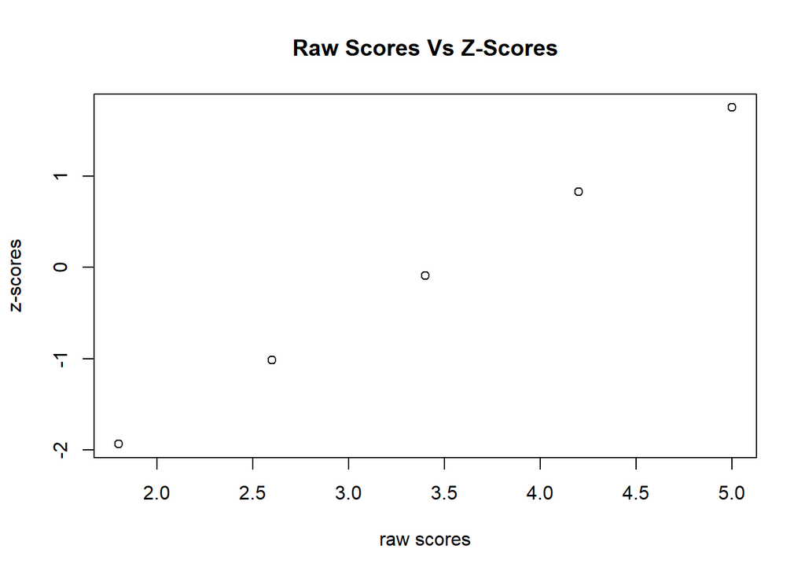

Plotting Raw Scores Against Z-scores

```r
plot(zscores$raw.scores,zscores$z.score,main = 'Raw Scores Vs Z-Scores',xlab = 'raw scores',ylab = 'z-scores')
```

## Response

After running the doSummary() on the record for ‘monte.shaffer@gmail.com’, it is apparent that the mode is 4.2, the mean is 3.48, there are no NAN values, the length is 64 columns, the two pass and naïve variances are both .7528136 and the standard deviation is .8676483. Considering the plot created from plotting raw scores against z-scores we can conclude from Figure 9 that there is a strong positive linear relationship between raw scores and z-scores. This is because the z-score is calculated from the raw values, meaning the two are highly correlated.

# Adding mill.200 to Will and Denzel

Compare Will Smith and Denzel Washington. [See 03_n greater 1-v2.txt for the necessary functions and will-vs-denzel.txt for some sample code and in DROPBOX: __student_access___01_exploratory_data_analysis_02] You will have to create a new variable $millions.2000 that converts each movie’s $millions based on the $year of the movie, so all dollars are in the same time frame. You will need inflation data from about 1980-2020 to make this work.

## Get Data For Actors

```r
source(paste0(local.path,"/functions/functions-imdb.R"),local = T)

# Add mill.2000 column to Will's data frame with converted dollar values
nmid = "nm0000226"
will = grabFilmsForPerson(nmid)

nmid = "nm0000243"
denzel = grabFilmsForPerson(nmid)

will$movies.50
```

| rank | title | ttid | year | rated | minutes | genre | ratings | metacritic | votes | millions |
| --- | --- | --- | --- | --- | --- | --- | --- | --- | --- | --- |
| 1 | I Am Legend | tt0480249 | 2007 | PG-13 | 101 | Action, Adventure, Drama | 7.2 | 65 | 675400 | 256.39 |
| 2 | Suicide Squad | tt1386697 | 2016 | PG-13 | 123 | Action, Adventure, Fantasy | 6.0 | 40 | 588329 | 325.10 |
| 3 | Independence Day | tt0116629 | 1996 | PG-13 | 145 | Action, Adventure, Sci-Fi | 7.0 | 59 | 520758 | 306.17 |
| 4 | Men in Black | tt0119654 | 1997 | PG-13 | 98 | Action, Adventure, Comedy | 7.3 | 71 | 507748 | 250.69 |
| 5 | I, Robot | tt0343818 | 2004 | PG-13 | 115 | Action, Drama, Sci-Fi | 7.1 | 59 | 491638 | 144.80 |
| 6 | The Pursuit of Happyness | tt0454921 | 2006 | PG-13 | 117 | Biography, Drama | 8.0 | 64 | 438317 | 163.57 |
| 7 | Hancock | tt0448157 | 2008 | PG-13 | 92 | Action, Fantasy | 6.4 | 49 | 438025 | 227.95 |
| 8 | Men in Black II | tt0120912 | 2002 | PG-13 | 88 | Action, Adventure, Comedy | 6.2 | 49 | 337652 | 190.42 |
| 9 | Men in Black 3 | tt1409024 | 2012 | PG-13 | 106 | Action, Adventure, Comedy | 6.8 | 58 | 330111 | 179.02 |
| 10 | Hitch | tt0386588 | 2005 | PG-13 | 118 | Comedy, Romance | 6.6 | 58 | 292055 | 179.50 |

[output cut: 40 more lines]

## Get Inflation Data

```r
source(paste0(local.path,"/functions/functions-inflation.R"),local = T)
inflation_data = grabInflation()
```

## Adjust Denzel and Will Million Values

```r
will = convertDollars(will,inflation_data)
denzel = convertDollars(denzel,inflation_data)

head(will$movies.50)
```

|  | rank | title | ttid | year | rated | minutes | genre | ratings | metacritic | votes | millions | mill.2000 |
| --- | --- | --- | --- | --- | --- | --- | --- | --- | --- | --- | --- | --- |
| 1 | 1 | I Am Legend | tt0480249 | 2007 | PG-13 | 101 | Action, Adventure, Drama | 7.2 | 65 | 675400 | 256.39 | 212.9349 |
| 2 | 2 | Suicide Squad | tt1386697 | 2016 | PG-13 | 123 | Action, Adventure, Fantasy | 6.0 | 40 | 588329 | 325.10 | 233.2524 |
| 3 | 3 | Independence Day | tt0116629 | 1996 | PG-13 | 145 | Action, Adventure, Sci-Fi | 7.0 | 59 | 520758 | 306.17 | 336.0260 |
| 4 | 4 | Men in Black | tt0119654 | 1997 | PG-13 | 98 | Action, Adventure, Comedy | 7.3 | 71 | 507748 | 250.69 | 268.9646 |
| 5 | 5 | I, Robot | tt0343818 | 2004 | PG-13 | 115 | Action, Drama, Sci-Fi | 7.1 | 59 | 491638 | 144.80 | 131.9987 |
| 6 | 6 | The Pursuit of Happyness | tt0454921 | 2006 | PG-13 | 117 | Biography, Drama | 8.0 | 64 | 438317 | 163.57 | 139.7160 |

```r
head(denzel$movies.50)
```

|  | rank | title | ttid | year | rated | minutes | genre | ratings | metacritic | votes | millions | mill.2000 |
| --- | --- | --- | --- | --- | --- | --- | --- | --- | --- | --- | --- | --- |
| 1 | 1 | American Gangster | tt0765429 | 2007 | R | 157 | Biography, Crime, Drama | 7.8 | 76 | 384147 | 130.16 | 108.09943 |
| 2 | 2 | Training Day | tt0139654 | 2001 | R | 122 | Crime, Drama, Thriller | 7.7 | 69 | 382216 | 76.63 | 74.50980 |
| 3 | 3 | Inside Man | tt0454848 | 2006 | R | 129 | Crime, Drama, Mystery | 7.6 | 76 | 332149 | 88.51 | 75.60229 |
| 4 | 4 | The Equalizer | tt0455944 | 2014 | R | 132 | Action, Crime, Thriller | 7.2 | 57 | 326265 | 101.53 | 73.85216 |
| 5 | 5 | Man on Fire | tt0328107 | 2004 | R | 146 | Action, Crime, Drama | 7.7 | 47 | 324281 | 77.91 | 71.02224 |
| 6 | 6 | Flight | tt1907668 | 2012 | R | 138 | Drama, Thriller | 7.3 | 76 | 320428 | 93.77 | 70.32934 |

### Response

With converting all movie revenues to year 2000 dollars, we can tell that most of the movies Will Smith is in have higher revenue than the movies featuring Denzel Washington. We can also tell that Will Smith was in a movie that generated $336.03 million, which is considered an outlier. In general, we can see that the median revenue is the almost same between Will Smith and Denzel Washington, and Will Smith has a higher maximum revenue value than Denzel Washington.

# Will Vs Denzel

Build side-by-side box plots on several of the variables (including #6) to compare the two movie stars. After each box plot, write 2+ sentence describing what you are seeing, and what conclusions you can logically make. You will need to review what the box plot is showing with the box portion, the divider in the box, and the whiskers.

## Comparing Will vs Denzel Year 2000 Millions

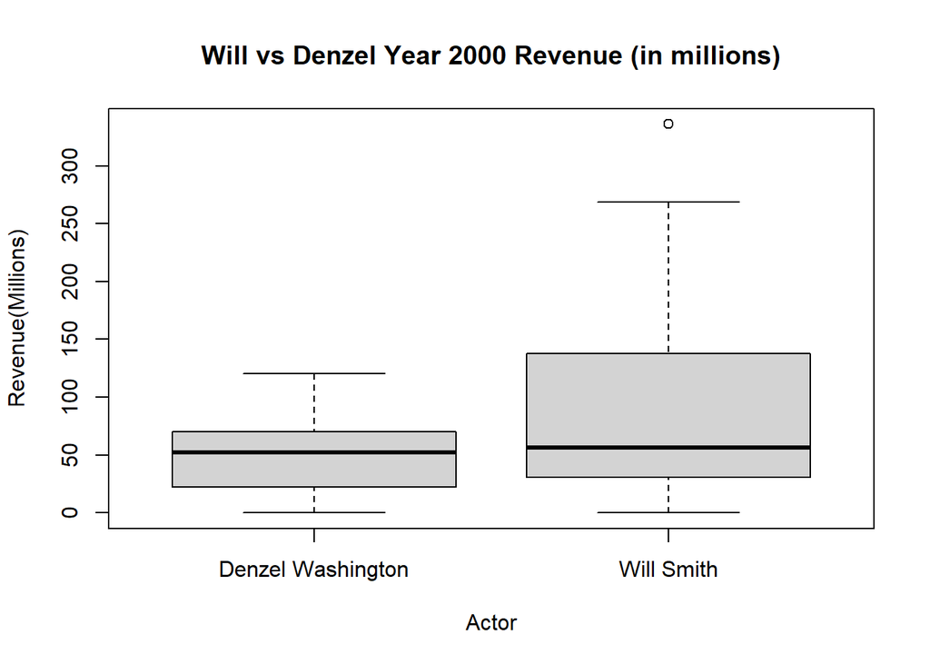

```r
boxplot(denzel$movies.50$mill.2000,will$movies.50$mill.2000,main = 'Will vs Denzel Year 2000 Revenue (in millions)', names = c('Denzel Washington', 'Will Smith'), xlab = 'Actor' , ylab = 'Revenue(Millions)')
```

### Response

Building a boxplot comparing the revenues (scaled to year 2000) between Will Smith and Denzel Washington (Figure 10), we can tell that Will Smith has a slightly higher median revenue than Denzel Washington. We can also conclude that fifty percent of Will Smith’s revenue values are between $30.45 million and $137.66 million and fifty percent of Denzel Washington’s revenue values are between $22.39 million and $70.06 million. This shows us that Will Smith’s revenue values are spread out more when compared to Denzel Washington’s’ values.

## Comparing Will vs Denzel Years

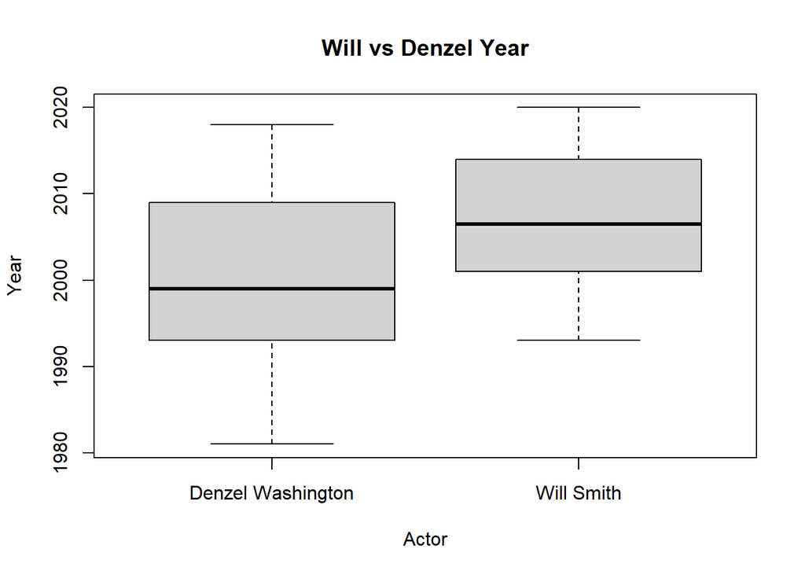

```r
boxplot(denzel$movies.50$year,will$movies.50$year,main = 'Will vs Denzel Year', names = c('Denzel Washington', 'Will Smith'), xlab = 'Actor' , ylab = 'Year')
```

### Response

Comparing Will Smith and Denzel Washington’s years using a boxplot (Figure 11), there are serval key findings. We can conclude that, for this data set, Denzel Washington appears in older movies when compared to Will Smith. We can also determine that Denzel Washington’s most recent film was before 2020, while Will Smith’s most recent film was in 2020. We can also conclude that half of the movies Will Smith has been featured in were after 2006, and the other half before 2006. Likewise, we can determine that half of the movies Denzel Washington has appeared in were after 1999, and the other half before 1999.

## Comparing Will vs Denzel Runtime

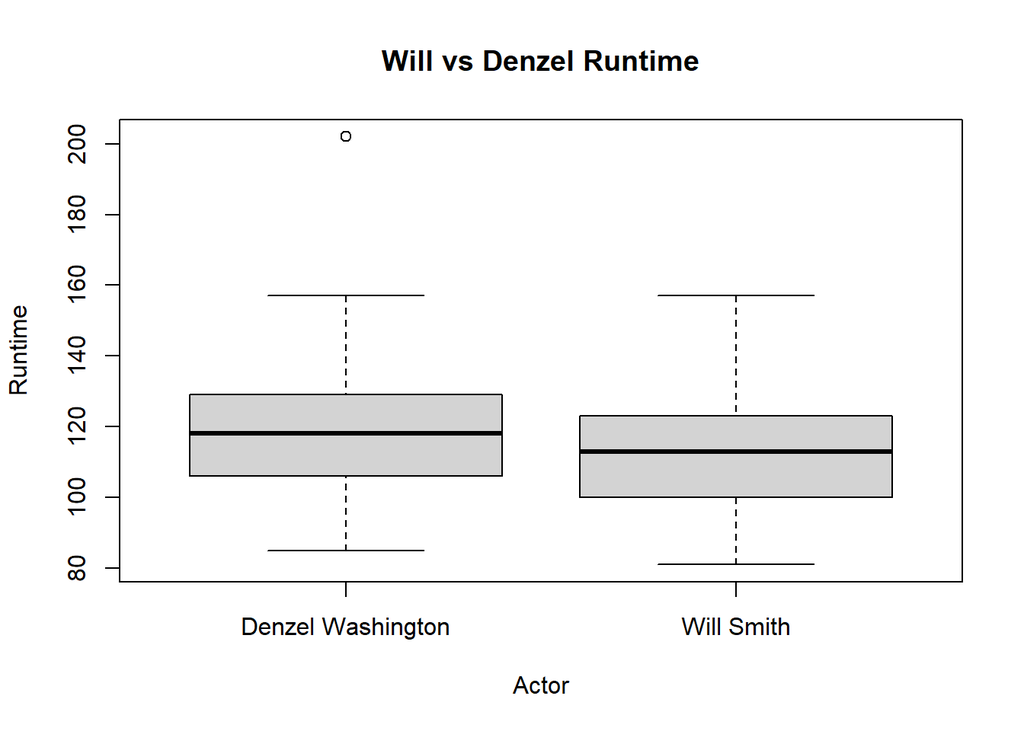

```r
boxplot(denzel$movies.50$minutes,will$movies.50$minutes,main = 'Will vs Denzel Runtime', names = c('Denzel Washington', 'Will Smith'), xlab = 'Actor' , ylab = 'Runtime')
```

### Response

Using a boxplot to compare Will Smith and Denzel Washington’s movie runtime(Figure 12), we can conclude that Denzel Washington has appeared in the longest movie in the data set. We can also conclude that Will Smith appeared in the shortest movie in the data set. Furthermore, we can conclude that the upper half of Denzel Washington’s runtime values are higher than Will Smith’s runtime values.